# Introduction to Data Science

Victor Coppin

2025-06-24

# 1 R Basics

This file follows the course *Introduction to Data Science by Rafael A. Irizarry*

**CASE STUDY : US murder rates by state**

> “*Imagine you live in Europe and are offered a job in a US company with many locations across all states.It is a great job, but news with headlines such as ”US Gun Homicide Rate Higher Than Other Developed Countries” have you worried. But then you remember that the US is a large and diverse country with 50 very different states as well as the District of Columbia (DC). California, for example, has a larger population than Canada, and 20 US states have populations larger than that of Norway. In some respects, the variability across states in the US is akin to the variability across countries in Europe. Furthermore, although not included in the charts above, the murder rates in Lithuania, Ukraine, and Russia are higher than 4 per 100,000. So perhaps the news reports that worried you are too superficial. You have options of where to live and want to determine the safety of each particular state. We will gain some insights by examining data related to gun homicides in the US during 2010 using R.*”[^1].

R was developed by statisticians as an interactive environment for data analysis  
Click here to read the History of R (PDF)  
- R is free and open source - It runs on all major platforms : Windows, macOS, UNIX/Linux - Scripts and data objects can be shared seamlessly across platforms - Active community : [Free resources for learning R](https://stats.stackexchange.com/questions/138/free-resources-for-learning-r)

## 1.1 Installation and packages

### 1.1.1 Scripts and Markdown

- **Create a new Script (.R)**: `Ctrl + Shift + N`
- **Save a Script or R Markdown file**: `Ctrl + S`

### 1.1.2 Packages

To install packages, inside the Console :

```r
install.packages("ggplot2") # install the ggplot2 library
install.packages("dslabs") # install the Harvard dslabs R package
installed.packages()[,"Package"] #list all installed packages
install.packages("tidyverse", dependencies = TRUE) # tells R to install the other things that are necessary for the package or packages to run smoothly.
install.packages(c("tidyverse", "dslabs")) # to install two packages at the same time
"ggplot2" %in% rownames(installed.packages()) # return TRUE if a package is already installed.
```

Note: >“We recommend installing packages through RStudio, rather than through R, and the code provided works in both R and RStudio. Once a package has been installed, it is technically added onto R (even if you use RStudio to install it), which is why packages must be re-installed when R is updated. However, since we use R through RStudio, any packages that are installed can be used in both R and RStudio, regardless of which one was used to install the packages”

Load a package into the R session Note :  
- to create a chunk code block : `Ctrl + Alt + I` - to run a chunk : `Ctrl + Shift + Enter` - Hides messages (*i.e.* from library calls) : `{r, message=FALSE}`

```r
library(dslabs)
```

### 1.1.3 Running commands

#### 1.1.3.1 shortcuts:

- **Run an entire script**: `Ctrl + Shift + Enter`
- **Run a single line of script**: `Ctrl+Enter` while the cursor is pointing to that specific line.

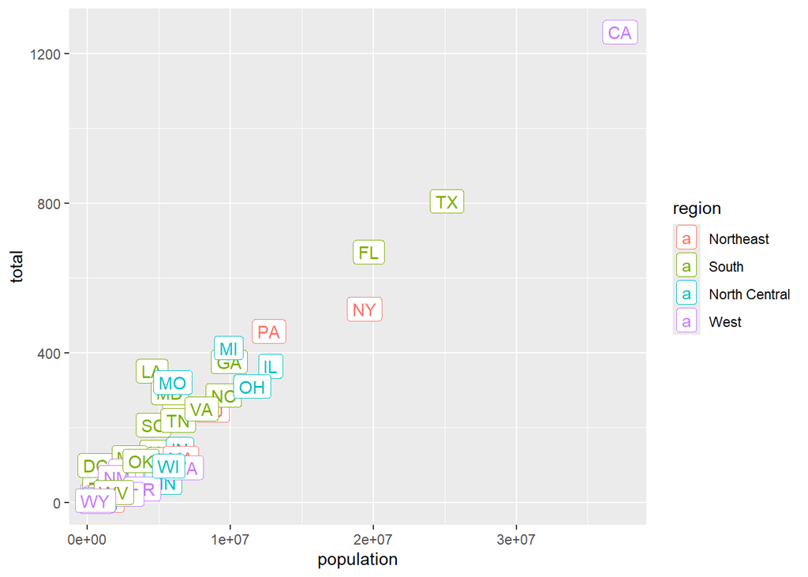

```r
library(tidyverse)
library(dslabs)
data(murders)

murders %>%
  ggplot(aes(population,total, label=abb, color=region ))+
  geom_label()
```

## 1.2 Objects: Variables, Functions, and Data Types

### 1.2.1 Variables

To define a variable we may use the assignment symbol: `<-`

Code to solve the equation : $x^2 + x - 1 = 0$ The quadratic formula gives us the solutions :
$$\dfrac{-b-\sqrt{b^2-4ac}}{2a} \quad \text{and} \quad
\dfrac{-b+\sqrt{b^2-4ac}}{2a}$$

```r
# assigning values to the variables
a <- 1
b <- 1
c <- -1

# solving the quadratic equation
(-b +sqrt(b^2-4*a*c))/(2*a)
```

```
## [1] 0.618034
```

```r
(-b -sqrt(b^2-4*a*c))/(2*a)
```

```
## [1] -1.618034
```

To see the value stored in a variable we ask R to evaluate `a` or more explicitly to show us the value with the `print()` function  
All the variables are saved in the workspace: `ls()` shows the names of the objects saved.

```r
a
```

```
## [1] 1
```

```r
print(a)
```

```
## [1] 1
```

```r
ls()
```

```
## [1] "a"       "b"       "c"       "murders"
```

### 1.2.2 Functions

R includes several predefined functions and most of the analysis pipelines we construct make extensive use of these. There are many more prebuilt functions and even more can be added through packages. These functions do not appear in the workspace because you did not define them, but they are available for immediate use. In general, **we need to use parentheses** to evaluate a function. If you type ls, the function is not evaluated and instead R shows you the code that defines the function. If you type `ls()` the function is evaluated and, as seen above, we see objects in the workspace. Unlike ls, most functions require one or more arguments. Below is an example of how we assign an object to the argument of the function log.

```r
log(8)
```

```
## [1] 2.079442
```

```r
log(a) #a was already assigned to 1
```

```
## [1] 0
```

#### 1.2.2.1 Help

You can find out what the function expects and what it does by reviewing the very useful manuals included in R.

```r
help("log")
?log # shorthand
```

**The help page** will show you what arguments the function is expecting. For example, log needs x and base to run. However, some arguments are required and others are optional. You can determine which arguments are optional by noting in the help document that a default value is assigned with `=`. Defining these is optional. For example, the base of the function log defaults to base = exp(1) making log the natural log by default.”

```r
args(log) # quick look at the argument without opening the help system
```

```
## function (x, base = exp(1))
## NULL
```

If no argument name is used, R assume arguments are in the order shown in the help page:

```r
log(x=8,base=2)
```

```
## [1] 3
```

```r
log(base=2, x=8) # if using arguments' names, we can include them in whatever order we want.
```

```
## [1] 3
```

```r
log(8,2)
```

```
## [1] 3
```

#### 1.2.2.2 Arithmetic and relational operators

Arithmetic and relational operators are functions that didn’t need parentheses to be evaluated. Note: In R, operators like `+`, `*`, or `%%` are actually functions, so you can call `help("+")` just like any function.

```r
5+3
5-1
5*3
10/2
2**2  # Exponentiation
2^3   # Exponentiation
5%%2  # Modulo
5%/%5 # Integer division

# Help for operators
help("+") # Give a list of all arithmetic operator not only "+"
?">"      # Help for all relational operators
```

### 1.2.3 Other pre-built objects

- Mathematical constants like $\pi$ and $\infty$ are represented as `pi` and `Inf` in R
- List all the available data sets : `data()` These data sets are objects that can be used by simply typing the name :`co2`

#### 1.2.3.1 Sequence Generation

Generate regular sequence

```r
seq(0, 10)              # generates a sequence from 0 to 10 by 1
```

```
##  [1]  0  1  2  3  4  5  6  7  8  9 10
```

```r
seq(0, 100, by = 10)    # from 0 to 100, incrementing by 10
```

```
##  [1]   0  10  20  30  40  50  60  70  80  90 100
```

```r
seq(0, 1, length.out = 11) # generates 11 equally spaced numbers from 0 to 1
```

```
##  [1] 0.0 0.1 0.2 0.3 0.4 0.5 0.6 0.7 0.8 0.9 1.0
```

#### 1.2.3.2 Sum

The `sum()` function returns the total of all values present in its arguments.

```r
x <- 10
y <- seq(0,x,by =1)
sum(y)
```

```
## [1] 55
```

```r
sum(1:4) # pass a vector to sum and it will add the elements together
```

```
## [1] 10
```

## 1.3 Data types

Variables in R can be of different types.The function class helps us determine what type of object we have:

```r
a <- 4
class(a)
```

```
## [1] "numeric"
```

### 1.3.1 Data Frame

The most common way of storing a dataset in R is in a data frame. Conceptually, we can think of a data frame as a table with rows representing observations and the different variables reported for each observation defining the columns. Data frames are particularly useful for datasets because we can combine **different data types into one object**.

A large proportion of data analysis challenges start with data stored in a data frame. For example, we stored the data for our motivating example in a data frame. You can access this dataset by loading the dslabs library and loading the murders dataset using the data function:

The `data()` function without arguments lists available datasets from currently loaded packages. To actually load a dataset, use it with the dataset name: `data(murders)`

```r
library(dslabs)
data(murders) # load the dataset "murders" into the environments (memory) allowing to work directly with
```

```r
class(murders) # check if murders is indeed a data.frame
```

```
## [1] "data.frame"
```

#### 1.3.1.1 Structure of an object

The function `str` shows us the structure of an object :

```r
str(murders)
```

```
## 'data.frame':    51 obs. of  5 variables:
##  $ state     : chr  "Alabama" "Alaska" "Arizona" "Arkansas" ...
##  $ abb       : chr  "AL" "AK" "AZ" "AR" ...
##  $ region    : Factor w/ 4 levels "Northeast","South",..: 2 4 4 2 4 4 1 2 2 2 ...
##  $ population: num  4779736 710231 6392017 2915918 37253956 ...
##  $ total     : num  135 19 232 93 1257 ...
```

```r
library(dplyr)
glimpse(murders) # For compact data view
```

```
## Rows: 51
## Columns: 5
## $ state      <chr> "Alabama", "Alaska", "Arizona", "Arkansas", "California", "…
## $ abb        <chr> "AL", "AK", "AZ", "AR", "CA", "CO", "CT", "DE", "DC", "FL",…
## $ region     <fct> South, West, West, South, West, West, Northeast, South, Sou…
## $ population <dbl> 4779736, 710231, 6392017, 2915918, 37253956, 5029196, 35740…
## $ total      <dbl> 135, 19, 232, 93, 1257, 65, 97, 38, 99, 669, 376, 7, 12, 36…
```

We can see that murders is a `data.frame` with 51 observations of 5 variables : - `$state`: a character variable like “Alabama” - `$abb` : character variable as the abbreviation of the state name - `$region` : factor, useful to store categorical data and more efficient than storing characters - `$population` and `$total` are numeric data

#### 1.3.1.2 The accessor : $

For our analysis, we will need to access the different variables represented by columns included in this data frame. To do this, we use the accessor operator `$`

```r
# Showing the first 6 lines of the dataset
head(murders)
```

```
##        state abb region population total
## 1    Alabama  AL  South    4779736   135
## 2     Alaska  AK   West     710231    19
## 3    Arizona  AZ   West    6392017   232
## 4   Arkansas  AR  South    2915918    93
## 5 California  CA   West   37253956  1257
## 6   Colorado  CO   West    5029196    65
```

```r
# Using the accessor operator to obtain the population column
murders$state
```

```
##  [1] "Alabama"              "Alaska"               "Arizona"
##  [4] "Arkansas"             "California"           "Colorado"
##  [7] "Connecticut"          "Delaware"             "District of Columbia"
## [10] "Florida"              "Georgia"              "Hawaii"
## [13] "Idaho"                "Illinois"             "Indiana"
## [16] "Iowa"                 "Kansas"               "Kentucky"
## [19] "Louisiana"            "Maine"                "Maryland"
## [22] "Massachusetts"        "Michigan"             "Minnesota"
## [25] "Mississippi"          "Missouri"             "Montana"
## [28] "Nebraska"             "Nevada"               "New Hampshire"
## [31] "New Jersey"           "New Mexico"           "New York"
## [34] "North Carolina"       "North Dakota"         "Ohio"
## [37] "Oklahoma"             "Oregon"               "Pennsylvania"
## [40] "Rhode Island"         "South Carolina"       "South Dakota"
## [43] "Tennessee"            "Texas"                "Utah"
## [46] "Vermont"              "Virginia"             "Washington"
## [49] "West Virginia"        "Wisconsin"            "Wyoming"
```

```r
# Determining how many entries are in a vector
pop <- murders$population
length(pop)
```

```
## [1] 51
```

```r
# Factors are another type of class :
class(murders$region)
```

```
## [1] "factor"
```

```r
levels(murders$region)
```

```
## [1] "Northeast"     "South"         "North Central" "West"
```

#### 1.3.1.3 Vectors: numerics, characters and logical

The object `murders$population` is not one number but several, it is a numeric vector of length 51. To store character strings, vectors can also be of class character. For example, the state names are characters: **Note**: use quote to distinguish between variable name and character strings

```r
class(murders$state)
```

```
## [1] "character"
```

```r
#assign a character to a variable name
a <- 1
a <- "a"
a
```

```
## [1] "a"
```

Logical vectors : TRUE/FALSE

```r
z <- 3 == 2 # == is a relational operator, asking if 3 is equal to 2
z
```

```
## [1] FALSE
```

```r
class(z)
```

```
## [1] "logical"
```

#### 1.3.1.4 Factors

We saw that in the murders data set, region is a factor of 4 levels.

```r
levels(murders$region)
```

```
## [1] "Northeast"     "South"         "North Central" "West"
```

In the background, R stores these levels as integers and keeps a map to keep track of the labels. This is more memory efficient than storing all the characters.

*The function reorder **lets us change the order of the levels of a factor variable based on a summary computed on a numeric vector.

**Reorder the levels of the region by the total number of murders rather than the alphabetical order**:

```r
region <- murders$region
value <- murders$total
region <- reorder(region,value, FUN = sum)
levels(region)
```

```
## [1] "Northeast"     "North Central" "West"          "South"
```

#### 1.3.1.5 Key Points about data frame :

- Data frames can be thought of as tables with rows representing observations and columns representing different variables.
- To access data from columns of a data frame, we use the dollar sign symbol, $, which is called the accessor.
- Data frames are a kind of lists : both can store different types of data (numeric, character,*etc.*), they both have named components and can be parsed/access with `$`, `[[]]` or `[]`. But Data frames is a special kind of list where : every components must be a vector of the same length, it is interpreted as a 2D table like a spreadsheet (rows x columns)

The order of the entries in the list `murders$population` preserves the order of the rows in our data table.

This means that each element in the vector correspond exactly to the same row in the original dataframe : - `murders$state[1]` is Alabama - `murders$population[1]` is the population of Alabama The index `1` in each column matches the first row of the table and that pattern continues for every row, which allows to manipulate or compare columns position by position.

# 2 Vectors and Sorting

In R, the most basic objects available to store data are vectors. As we have seen, complex datasets can usually be broken down into components that are vectors. For example, in a data frame, each column is a vector.

## 2.1 Creating vectors

We can create vectors using the function `c`, which stands for *concatenate* :

```r
codes <- c(380,124,818)
codes
```

```
## [1] 380 124 818
```

We can also create character vectors. We use the quotes to denote that the entries are characters rather than variable names.

```r
countries <- c("Italy", "Canada", "Egypt") # We can also use single quotes 'Italy'
countries
```

```
## [1] "Italy"  "Canada" "Egypt"
```

### 2.1.1 Sequences

Another useful function for creating vectors generates sequences:

```r
seq(1, 10)
```

```
##  [1]  1  2  3  4  5  6  7  8  9 10
```

```r
1:10 # if we want consecutive integers we can use this shorthand
```

```
##  [1]  1  2  3  4  5  6  7  8  9 10
```

*Note*: When we use these functions, R produces integers, not numeric, because they are typically used to index

### 2.1.2 Subsetting : access data

We use square brackets to access specific elements of a vector.

```r
codes <- c("Cannes" = 06400, "Laon" = 02000, "Reims" = 51100, "Versailles" = 78000)
codes[2] # Access to the second index : Laon 2000
```

```
## Laon
## 2000
```

```r
codes[c(1, 2)] # Access the 2 first elements
```

```
## Cannes   Laon
##   6400   2000
```

If the elements have names, we can also access the entries using these names.

```r
codes["Laon"]
```

```
## Laon
## 2000
```

### 2.1.3 Coercion

In general, coercion is an attempt by R to be flexible with data types. When an entry does not match the expected, some of the prebuilt R functions try to guess what was meant before throwing an error. This can also lead to confusion. Failing to understand coercion can drive programmers crazy when attempting to code in R since it behaves quite differently from most other languages in this regard. Let’s learn about it with some examples. We said that vectors must be all of the same type. So if we try to combine, say, numbers and characters, you might expect an error:

```r
x <- c(1, "Canada", 3)
```

We don’t get, any error, neither warning : **R coerced the data into characters**

```r
class(x)
```

```
## [1] "character"
```

R also offers functions to change from one type to another.

```r
x <- 1:5
y <- as.character(x) # Turn numbers into characters
y
```

```
## [1] "1" "2" "3" "4" "5"
```

```r
z <- as.numeric(y) # Turn it back to numeric
z
```

```
## [1] 1 2 3 4 5
```

When a function tries to coerce one type to another and encounters an impossible case, it usually gives us a warning and turns the entry into a special value called an NA for “not available”. For example:

```r
x <- c("1","b","3")
as.numeric(x)
```

```
## Warning: NAs introduced by coercion
```

```
## [1]  1 NA  3
```

#### 2.1.3.1 Exercise

1. Use the function `c()` to create a vector with the average high temperatures in January for Beijing, Lagos, Paris, Rio de Janeiro, San Juan, and Toronto, which are 35, 88, 42, 84, 81, and 30 degrees Fahrenheit. Call the object `temp`.
2. Now create a vector with the city names and call the object `city`.
3. Use the `names()` function and the objects defined in the previous exercises to associate the temperature data with its corresponding city.
4. Use the `[` and `:` operators to access the temperature of the first three cities on the list.
5. Use the `[` operator to access the temperature of Paris and San Juan.
6. Use the `:` operator to create a sequence of numbers 12,13,14,…,73.
7. Create a vector containing all the positive odd numbers smaller than 100.
8. Create a vector of numbers that starts at 6, does not pass 55, and adds numbers in increments of 4/7: 6, 6 + 4/7, 6 + 8/7, and so on. How many numbers does the list have? (Hint: use `seq()` and `length()`)
9. What is the class of the following object `a <- seq(1, 10, 0.5)`?
10. What is the class of the following object `a <- seq(1, 10)`

```r
# 1 & 2: Create vectors
temp <- c(35,88,42,84,81,30)
city <- c("Beijing","Lagos","Paris","Rio de Janeiro","San Juan", "Toronto")
# 3: Assign the city names to the temp vector
names(temp) <- city
# 4: Access the temperature of the first 3 cities (indexing starts at 1 in R)
temp[1:3] # NOT temp[0:3] — index 0 does nothing in R
```

```
## Beijing   Lagos   Paris
##      35      88      42
```

```r
# 5: Access the temperature of Paris and San Juan
temp[c("Paris", "San Juan")]
```

```
##    Paris San Juan
##       42       81
```

```r
# 6: Sequence from 12 to 73
12:73
```

```
##  [1] 12 13 14 15 16 17 18 19 20 21 22 23 24 25 26 27 28 29 30 31 32 33 34 35 36
## [26] 37 38 39 40 41 42 43 44 45 46 47 48 49 50 51 52 53 54 55 56 57 58 59 60 61
## [51] 62 63 64 65 66 67 68 69 70 71 72 73
```

```r
# 7: Positive odd numbers < 100
seq(1, 100, by = 2)
```

```
##  [1]  1  3  5  7  9 11 13 15 17 19 21 23 25 27 29 31 33 35 37 39 41 43 45 47 49
## [26] 51 53 55 57 59 61 63 65 67 69 71 73 75 77 79 81 83 85 87 89 91 93 95 97 99
```

```r
# 8: Create a sequence starting at 6, going up in steps of 4/7 until ≤ 55
increment <- seq(6, 55, by = 4 / 7)
length(increment)
```

```
## [1] 86
```

```r
# 9: Class of a <- seq(1, 10, 0.5)
a <- seq(1, 10, 0.5)
class(a)
```

```
## [1] "numeric"
```

```r
# 10: Class of a <- seq(1, 10)
a <- seq(1, 10)
class(a)
```

```
## [1] "integer"
```

## 2.2 Sort

**Say we want to rank the states from least to most gun murders**. The function sort sorts a vector in increasing order. We can therefore see the largest number of gun murders by typing:

```r
sort(murders$total)
```

```
##  [1]    2    4    5    5    7    8   11   12   12   16   19   21   22   27   32
## [16]   36   38   53   63   65   67   84   93   93   97   97   99  111  116  118
## [31]  120  135  142  207  219  232  246  250  286  293  310  321  351  364  376
## [46]  413  457  517  669  805 1257
```

However, this does not give us information about which states have which murder totals. For example, we don’t know which state had 1257.

### 2.2.1 Order

The function `order` is closer to what we want. It takes a vector as input and returns the vector of indexes that sorts the input vector. This may sound confusing so let’s look at a simple example. We can create a vector and sort it:

```r
x <- c(31, 4, 15,92,65)
sort(x)
```

```
## [1]  4 15 31 65 92
```

Rather than sort the input vector, the function order returns the index that sorts input vector:

```r
order(x) # As 4 is the smallest value, order return it's index 2
```

```
## [1] 2 3 1 5 4
```

How does this help us order the states by murders? First, remember that the entries of vectors you access with $ follow the same order as the rows in the table. For example, these two vectors containing state names and abbreviations, respectively, are matched by their order:

```r
murders$state[1:6]
```

```
## [1] "Alabama"    "Alaska"     "Arizona"    "Arkansas"   "California"
## [6] "Colorado"
```

```r
murders$abb[1:6]
```

```
## [1] "AL" "AK" "AZ" "AR" "CA" "CO"
```

This means we can order the state names by their total murders. We first obtain the index that orders the vectors according to murder totals and then index the state names vector:

```r
ind <- order(murders$total) # Get indices of states sorted by total murders
murders$state[ind]          # Return states ordered by increasing murders
```

```
##  [1] "Vermont"              "North Dakota"         "New Hampshire"
##  [4] "Wyoming"              "Hawaii"               "South Dakota"
##  [7] "Maine"                "Idaho"                "Montana"
## [10] "Rhode Island"         "Alaska"               "Iowa"
## [13] "Utah"                 "West Virginia"        "Nebraska"
## [16] "Oregon"               "Delaware"             "Minnesota"
## [19] "Kansas"               "Colorado"             "New Mexico"
## [22] "Nevada"               "Arkansas"             "Washington"
## [25] "Connecticut"          "Wisconsin"            "District of Columbia"
## [28] "Oklahoma"             "Kentucky"             "Massachusetts"
## [31] "Mississippi"          "Alabama"              "Indiana"
## [34] "South Carolina"       "Tennessee"            "Arizona"
## [37] "New Jersey"           "Virginia"             "North Carolina"
## [40] "Maryland"             "Ohio"                 "Missouri"
## [43] "Louisiana"            "Illinois"             "Georgia"
## [46] "Michigan"             "Pennsylvania"         "New York"
## [49] "Florida"              "Texas"                "California"
```

```r
murders$state[tail(ind, 3)] # last 3 states in the sorted index
```

```
## [1] "Florida"    "Texas"      "California"
```

### 2.2.2 Entry with the largest values : `max` and `which.max`

If we are only interested in the entry with the largest value, we can use `max` for the value and `which.max` for the index of the largest value (idem for `min` and `which.min`)

```r
max(murders$total)
```

```
## [1] 1257
```

```r
i_max <- which.max(murders$total)
murders$state[i_max]
```

```
## [1] "California"
```

### 2.2.3 Rank

The rank() function gives us the ranks of the items in the original vector.

```r
x <- c(31, 4, 15,92,65)

sort_x <- sort(x)
order_x <- order(x)
rank_x <- rank(x)

# We construct a data frame to compare the behavior of each function
# Use `=` for naming argument inside functions
compare_sort_function_df <- data.frame(
  Original = x,         # Original values
  Sorted   = sort_x,    # Sorted values (increasing)
  Ordered  = order_x,   # Index positions to sort the original vector
  Ranked   = rank_x     # Rank of each value in the original vector
)

print(compare_sort_function_df)
```

```
##   Original Sorted Ordered Ranked
## 1       31      4       2      3
## 2        4     15       3      1
## 3       15     31       1      2
## 4       92     65       5      5
## 5       65     92       4      4
```

In the table below, we observe that:

- `sort()` returns the values of x in increasing order.
- `order()` returns the indices that would sort the vector. For example, in the first row, 2 means the smallest value is at position 2 in x.
- `rank()` returns the rank (position in the sorted vector) of each value in x. For example, in the first row, the value 3 means that x[1] (*i.e.* 31) is the third smallest value.

**Note**: If `rank(x)` gives you the ranks of x from lowest to highest, `rank(-x)` gives you the ranks from highest to lowest.

## 2.3 Vector arithmetics

> “*California had the most murders, but does this mean it is the most dangerous state? What if it just has many more people than any other state? We can quickly confirm that California indeed has the largest population:*

```r
 # Name of the state with the max population
murders$state[which.max(murders$population)]
```

```
## [1] "California"
```

> “*with over 37 million inhabitants. It is therefore unfair to compare the totals if we are interested in learning how safe the state is. What we really should be computing is the murders per capita. The reports we describe in the motivating section used murders per 100,000 as the unit. To compute this quantity, the powerful vector arithmetic capabilities of R come in handy.*”

In R, operations on vectors follow the usual mathematical rules for vectors — they are applied element by element (*i.e.*, component-wise). For example, adding two vectors of the same length will return a new vector with each element being the sum of corresponding elements.

```r
inches <- c(69, 62, 66, 70, 70, 73, 67, 73, 67, 70)

# Convert inches to centimeters
# This multiplies each element of the vector `inches` by 2.54
inches * 2.54
```

```
##  [1] 175.26 157.48 167.64 177.80 177.80 185.42 170.18 185.42 170.18 177.80
```

If we have two vectors of the same length and we add them in R, the operation is performed entry by entry, as follows:
$$\begin{pmatrix}
a \\
b \\
c \\
d
\end{pmatrix}
+
\begin{pmatrix}
e \\
f \\
g \\
h
\end{pmatrix}
=
\begin{pmatrix}
a + e \\
b + f \\
c + g \\
d + h
\end{pmatrix}$$
The same rule applies to other operations such as subtraction (-), multiplication (*), and division (/).

This means we can compute the murder rate (per 100,000 population) using simple vectorized arithmetic:

```r
murder_rate <- murders$total/murders$population * 100000
```

We can then use this new metric to find the state with the highest murder rate:

```r
murders$state[which.max(murder_rate)]
```

```
## [1] "District of Columbia"
```

#### 2.3.0.1 Exercise

- Compute the per 100,000 murder rate for each state and store it in the object murder_rate.
- Then compute the average murder rate for the US using the function mean.

What is the average?

```r
murder_rate
```

```
##  [1]  2.8244238  2.6751860  3.6295273  3.1893901  3.3741383  1.2924531
##  [7]  2.7139722  4.2319369 16.4527532  3.3980688  3.7903226  0.5145920
## [13]  0.7655102  2.8369608  2.1900730  0.6893484  2.2081106  2.6732010
## [19]  7.7425810  0.8280881  5.0748655  1.8021791  4.1786225  0.9992600
## [25]  4.0440846  5.3598917  1.2128379  1.7521372  3.1104763  0.3798036
## [31]  2.7980319  3.2537239  2.6679599  2.9993237  0.5947151  2.6871225
## [37]  2.9589340  0.9396843  3.5977513  1.5200933  4.4753235  0.9825837
## [43]  3.4509357  3.2013603  0.7959810  0.3196211  3.1246001  1.3829942
## [49]  1.4571013  1.7056487  0.8871131
```

```r
#?mean
mean(murder_rate)
```

```
## [1] 2.779125
```

The average murder rate across US states is approximately 2.78 per 100,000 population.

## 2.4 Indexing

> *“Imagine you are moving from Italy where, according to an ABC news report, the murder rate is only 0.71 per 100,000. You would prefer to move to a state with a similar murder rate.”*

**A powerful feature of R is that we can use logical vectors to index other vectors.**  
When we compare a vector to a number, R performs the comparison **element by element**, returning a logical vector.

### 2.4.1 Subsetting with logicals

Here’s an example based on the scenario above:

```r
# Create a logical vector: TRUE for states with murder rate ≤ 0.71
ind <- murder_rate <= 0.71
```

The object ind is a logical vector that is TRUE for each state with a murder rate lower than or equal to 0.71.

We can now use this logical vector to extract the corresponding state names:

```r
# Return the states where the murder rate is ≤ 0.71
murders$state[ind]
```

```
## [1] "Hawaii"        "Iowa"          "New Hampshire" "North Dakota"
## [5] "Vermont"
```

### 2.4.2 Logical operators

> “*Suppose we like the mountains and we want to move to a safe state in the western region of the country. We want the murder rate to be at most 1.*”

In this case, we want two different things to be true. Here we can use the logical operator `and`, which in R is represented with `&`. This operation results in TRUE only when both logicals are TRUE.

```r
# Creation of two logicals
west <- murders$region == "West"
safe <- murder_rate <=1

# And operator to get a vector of logicals that satisfy both conditions
ind <- west & safe
```

```r
print(west[2])
```

```
## [1] TRUE
```

```r
print(safe[2])
```

```
## [1] FALSE
```

```r
print(ind[2])
```

```
## [1] FALSE
```

We can use the & to get a vector of logicals that tells us which states satisfy both conditions:

```r
murders$state[ind]
```

```
## [1] "Hawaii"  "Idaho"   "Oregon"  "Utah"    "Wyoming"
```

### 2.4.3 Which

> *Suppose we want to look up California’s murder rate.*

For this type of operation, it is convenient to convert vectors of logicals into indexes instead of keeping long vectors of logicals. The function which tells us which entries of a logical vector are TRUE. So we can type:

```r
ind <- which(murders$state == "California")
murder_rate[ind]
```

```
## [1] 3.374138
```

# 3 Summary of functions used

[output not shown]

[^1]: Source: *Introduction to Data Science* by Rafael A. Irizarry